# Question

There are four types of end behavior in polynomials (seen by zooming out on the graph and looking far left or far right):

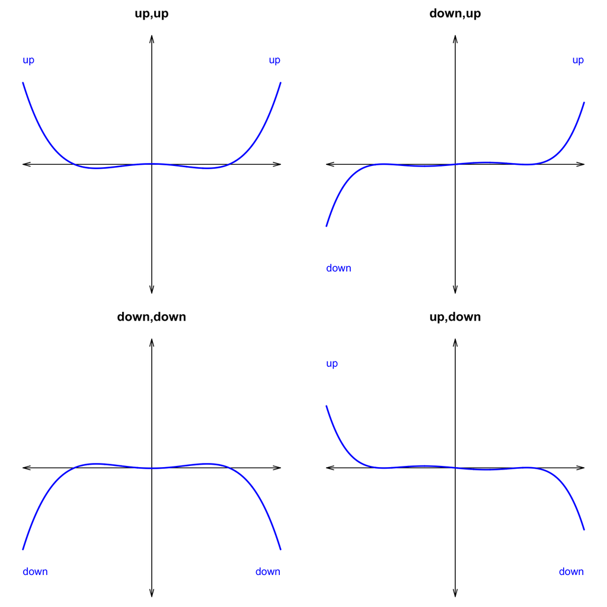

**For each polynomial, state the end behavior.**

1. $f(x)~=~{-2}x^{6}-{4}x^{5}+{9}x^{4}-{3}x^{3}-{8}x^{2}-{2}$
- End behavior for $f(x)$ is ##ANSWER1##.
2. $g(x)~=~{-7}x^{5}+{5}x^{3}-{5}x^{2}-{4}x+{2}$
- End behavior for $g(x)$ is ##ANSWER2##.
3. $h(x)~=~{9}x^{7}+{3}x^{6}-{7}x^{5}+{4}x^{4}-{5}x^{3}+{9}x+{8}$
- End behavior for $h(x)$ is ##ANSWER3##.
4. $i(x)~=~{-3}x^{7}-{6}x^{5}-{8}x^{4}-{3}x^{3}+x^{2}+{8}x+{5}$
- End behavior for $i(x)$ is ##ANSWER4##.
5. $j(x)~=~{-2}x^{8}+{3}x^{7}+{4}x^{6}-{7}x^{5}+{2}x^{4}-{3}x^{3}-{5}x^{2}+{8}x-{1}$
- End behavior for $j(x)$ is ##ANSWER5##.
6. $k(x)~=~{9}x^{6}-{4}x^{5}+{9}x^{4}+{8}x^{3}-{9}x^{2}+x$
- End behavior for $k(x)$ is ##ANSWER6##.
7. $l(x)~=~{-8}x^{8}+{2}x^{7}-{4}x^{6}+{7}x^{5}-{9}x^{4}-{8}x^{3}-{3}x^{2}+{9}$
- End behavior for $l(x)$ is ##ANSWER7##.
8. $m(x)~=~{-6}x^{7}-{9}x^{6}+{2}x^{5}-{4}x^{4}+{9}x^{3}+x^{2}-{6}x-{8}$
- End behavior for $m(x)$ is ##ANSWER8##.

## Answerlist

- up,up
- down,up
- down,down
- up,down
- up,up
- down,up
- down,down
- up,down
- up,up
- down,up
- down,down
- up,down
- up,up
- down,up
- down,down
- up,down
- up,up
- down,up
- down,down
- up,down
- up,up
- down,up
- down,down
- up,down
- up,up
- down,up
- down,down
- up,down
- up,up
- down,up
- down,down
- up,down

# Solution

For each polynomial, consider the highest-degree term.

|  | lead degree even | lead degree odd |
| --- | --- | --- |
| lead coefficient positive | up,up | down,up |
| lead coefficient negative | down,down | up,down |

1. The highest-degree term of $f(x)$ is ${-2}x^{6}$. The coefficient is negative. The degree is even. Thus, the end behavior is down,down.
2. The highest-degree term of $g(x)$ is ${-7}x^{5}$. The coefficient is negative. The degree is odd. Thus, the end behavior is up,down.
3. The highest-degree term of $h(x)$ is ${9}x^{7}$. The coefficient is positive. The degree is odd. Thus, the end behavior is down,up.
4. The highest-degree term of $i(x)$ is ${-3}x^{7}$. The coefficient is negative. The degree is odd. Thus, the end behavior is up,down.
5. The highest-degree term of $j(x)$ is ${-2}x^{8}$. The coefficient is negative. The degree is even. Thus, the end behavior is down,down.
6. The highest-degree term of $k(x)$ is ${9}x^{6}$. The coefficient is positive. The degree is even. Thus, the end behavior is up,up.
7. The highest-degree term of $l(x)$ is ${-8}x^{8}$. The coefficient is negative. The degree is even. Thus, the end behavior is down,down.
8. The highest-degree term of $m(x)$ is ${-6}x^{7}$. The coefficient is negative. The degree is odd. Thus, the end behavior is up,down.

# Meta-information

extype: cloze exclozetype: schoice|schoice|schoice|schoice|schoice|schoice|schoice|schoice exsolution: 0010|0001|0100|0001|0010|1000|0010|0001 exname: polynomial_ends_B